# Analiza czynników wpływająca na poziom spalania paliwa w samochodach

## Wprowadzenie

Celem projektu jest budowa modelu liniowego dla spalania w danych dotyczących samochodów osobowych.

### Instalacja potrzebnych bibliotek:

```r
library(raster)
library(readr)
library(lmtest)
library(olsrr)
library(ggplot2)
library(bootStepAIC)
library(dplyr)
library(nlme)
library(car)
library(randtests)
library(strucchange)
library(stringr)
library(corrgram)
```

### Wczytanie danych z pliku cars.csv i wyświetlenie ich:

```r
tabela<- read.csv(file="cars.csv", header=TRUE, sep="," )
glimpse(tabela)
```

```
## Observations: 314
## Variables: 9
## $ mpg          <dbl> 24.0, 21.0, 31.5, 19.4, 18.0, 29.0, 19.0, 26.0, 3...
## $ cylinders    <int> 4, 6, 4, 6, 6, 4, 6, 4, 4, 6, 4, 4, 6, 4, 6, 8, 4...
## $ displacement <dbl> 90, 200, 89, 232, 225, 68, 225, 122, 97, 168, 156...
## $ horsepower   <int> 75, 85, 71, 90, 105, 49, 100, 80, 78, 120, 92, 10...
## $ weight       <int> 2108, 2587, 1990, 3210, 3121, 1867, 3630, 2451, 2...
## $ acceleration <dbl> 15.5, 16.0, 14.9, 17.2, 16.5, 19.5, 17.7, 16.5, 1...
## $ year         <int> 74, 70, 78, 78, 73, 73, 77, 74, 77, 76, 81, 78, 7...
## $ origin       <int> 2, 1, 2, 1, 1, 2, 1, 1, 2, 2, 1, 1, 1, 3, 1, 1, 3...
## $ name         <fct> fiat 128, ford maverick, volkswagen scirocco, amc...
```

Zmienne **mpg**, **displacement**, **weight** wyrażone są w jednostkach amerykańskich, natomiast zmienna **year** jest wyrażona w dwucyfrowym formacie. Zmieniono je na jednostki zwyczjawo używane w Polsce przy użyciu funkcji replace:

```r
#Zamiana jednostki wagi na  kg
tabela$weight<- replace(tabela$weight, TRUE, round(tabela$weight/2.2046,2))
#Aby przeliczyć mpg (mile na galon) na l/100 km, trzeba podzielić 235 przez wynik spalania
tabela$mpg<- replace(tabela$mpg, TRUE, round(235/tabela$mpg,2))
# zamianna cal szesciennych na l (cal szescienny = 16,387cm^3)
tabela$displacement<-  replace(tabela$displacement, TRUE, round((tabela$displacement*16.387), 2))
tabela$year<- replace(tabela$year, TRUE, tabela$mpg+1900)
names(tabela)[1]<- "burned liters/100km"
```

#### Uznano zmienną **name** za zbyt szczegółową, dlatego postanowiono złoagodzić krytarium podziału do samej marki nie uwzględniajac modelu.

```r
tabela$name <- word(tabela$name, 1)
```

#### W zmiennej **name** było kilka literówek, dlatego postanowiono je poprawić.

```r
tabela$name<- gsub("chevy", "chevrolet", tabela$name)
tabela$name <- gsub('maxda', 'mazda', tabela$name)
tabela$name <- gsub('chevroelt', 'chevrolet', tabela$name)
tabela$name <- gsub('mercedes benz', 'mercedes-benz', tabela$name)
tabela$name <- gsub('toyouta', 'toyota', tabela$name)
tabela$name <- gsub('vokswagen', 'volkswagen', tabela$name)
```

### Zależność między spalaniem a marką samochodu

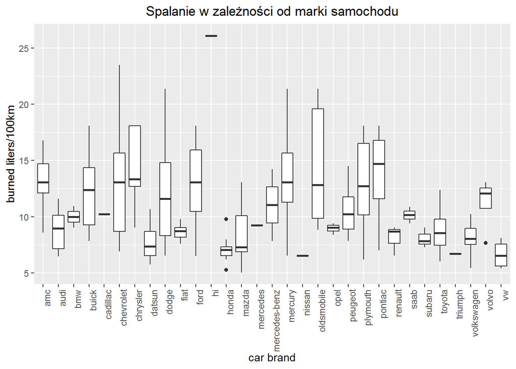

#### Zmienna **name** zmieniono na zmienną kategoryczną:

```r
(unique(tabela$name))
```

```
##  [1] "fiat"          "ford"          "volkswagen"    "amc"
##  [5] "plymouth"      "mercedes-benz" "dodge"         "pontiac"
##  [9] "mazda"         "mercury"       "toyota"        "buick"
## [13] "chevrolet"     "peugeot"       "renault"       "honda"
## [17] "datsun"        "chrysler"      "audi"          "vw"
## [21] "oldsmobile"    "volvo"         "opel"          "bmw"
## [25] "subaru"        "cadillac"      "nissan"        "mercedes"
## [29] "hi"            "saab"          "triumph"
```

```r
tabela$name<- factor(tabela$name)
levels(tabela$name)<- c(1:33)
```

### Wyświetlono podstawowe statystyki opisowe:

```r
summary(tabela)
```

```
##  burned liters/100km   cylinders     displacement    horsepower
##  Min.   : 5.04       Min.   :3.00   Min.   :1114   Min.   : 46.0
##  1st Qu.: 8.10       1st Qu.:4.00   1st Qu.:1606   1st Qu.: 75.0
##  Median :10.22       Median :4.00   Median :2474   Median : 95.0
##  Mean   :11.21       Mean   :5.49   Mean   :3183   Mean   :104.6
##  3rd Qu.:13.43       3rd Qu.:8.00   3rd Qu.:4805   3rd Qu.:128.0
##  Max.   :26.11       Max.   :8.00   Max.   :7456   Max.   :230.0
##
##      weight        acceleration        year          origin
##  Min.   : 731.6   Min.   : 8.00   Min.   :1905   Min.   :1.000
##  1st Qu.:1003.5   1st Qu.:13.70   1st Qu.:1908   1st Qu.:1.000
##  Median :1270.5   Median :15.50   Median :1910   Median :1.000
##  Mean   :1349.2   Mean   :15.49   Mean   :1911   Mean   :1.608
##  3rd Qu.:1651.9   3rd Qu.:17.00   3rd Qu.:1913   3rd Qu.:2.000
##  Max.   :2331.5   Max.   :23.70   Max.   :1926   Max.   :3.000
##
##       name
##  6      : 37
##  11     : 31
##  22     : 26
##  1      : 25
##  9      : 24
##  27     : 23
##  (Other):148
```

### Przedstawiono również macierz korelacji

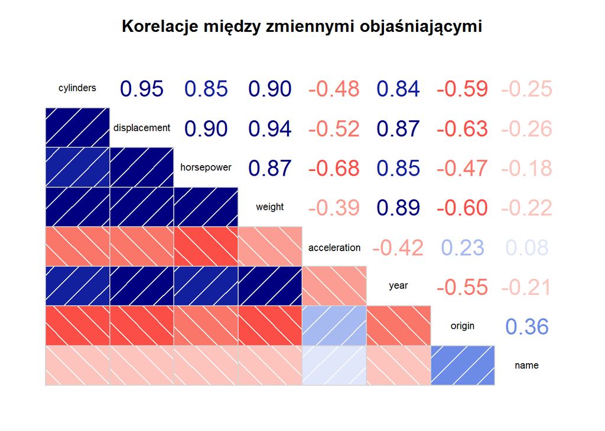

Zmienna **year** jest mocno skorelowana z większością zmiennych objaśniających, dlatego prawdopodobnie będziemy musieli usunąć ją z modelu. Ponadto zmienne **cylinders**, **displacement**, **horsepower** oraz **weight** są mocno ze sobą skorelowane. Może to sztucznie zawyżać współczynnik R^2.

## Wizulizacja:

### Zależność między liczbą spalanych l/100km, a wagą samochodu:

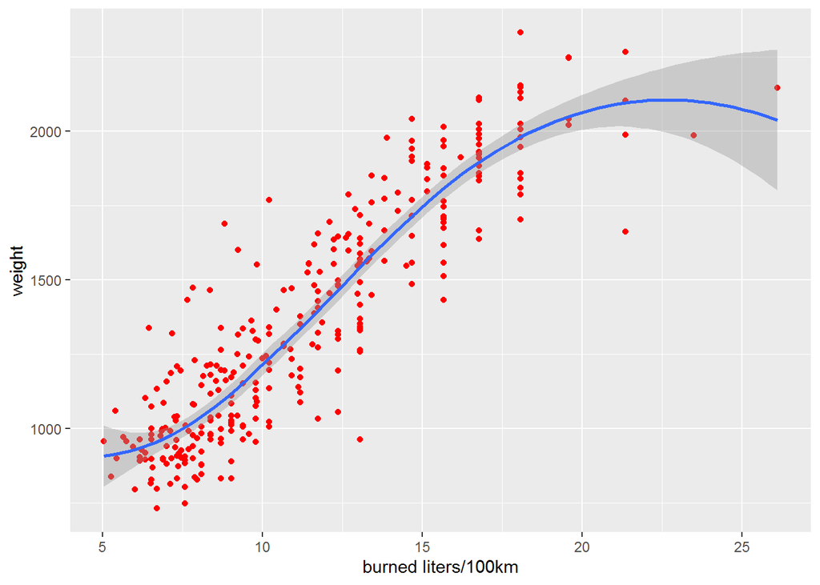

### Zależność pokazująca jak przyspieszenie i pojemność silnika wpływa na spalanie samochodu

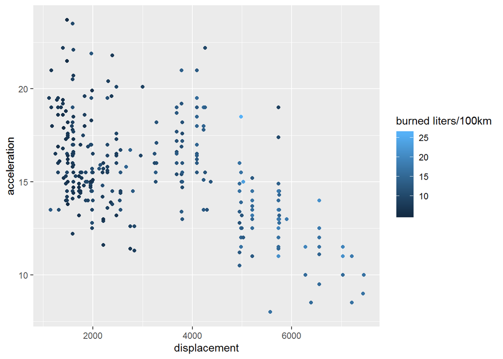

### Zależność pokazuje ile samochody w zależności od miejsca produkcji, liczby cylindrów i mocy w koniach mechanicznych spalają l/100km

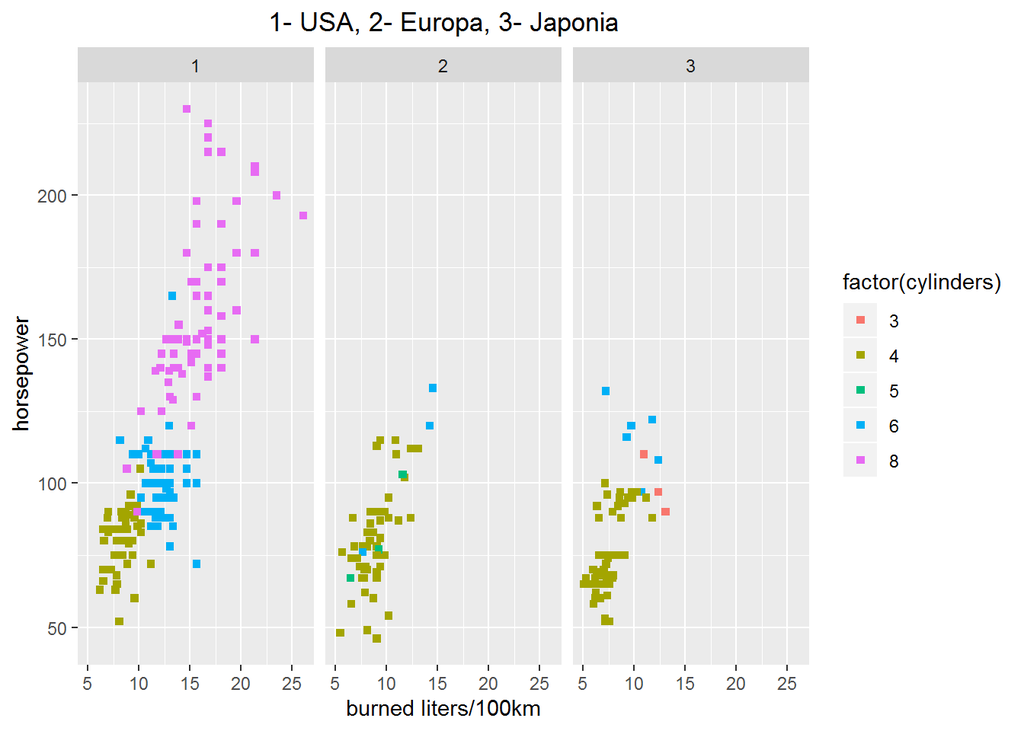

### Hipotezy na podstawie wykresów i statystyki opisowej:

1. Waga samochodu będzie bardzo istotna w modelu opisującym spalenie, wraz z wzrostem wagi będzie wzrastać ilośc spalania litrów na 100km. Hipoteza na podstawie wysokiej korelacji między tymi zmiennymi oraz pierwszym wykresie.
2. Czym wieksza objętość silnika tym większe spalanie.
3. Auta z mniejszą ilością cylindrów spalają mniej paliwa.

### Następnie wyliczono współczynniki zmienności i przedstawiono w tabeli:

```r
nazwy<- colnames(tabela)
wsp_zmien<- sapply(tabela, cv)
zmiennosc<- data.frame(zmienna = nazwy, wspolczynnik_zmienosci= wsp_zmien)
rownames(zmiennosc)<- c()
print (zmiennosc)
```

```
##               zmienna wspolczynnik_zmienosci
## 1 burned liters/100km             34.8521262
## 2           cylinders             31.1658992
## 3        displacement             54.0540474
## 4          horsepower             36.4704856
## 5              weight             28.8995755
## 6        acceleration             17.6557498
## 7                year              0.2044082
## 8              origin             51.0293964
## 9                name             64.0237849
```

##### W przypadku zmiennej **year** współczynnik był zdecydowanie mniejszy od 10%, wyniósł w przybliżeniu 0,2%, dlatego podjęto decyzję o nieuwzględnianiu jej w modelu.

### Wstępny model prezntuje się w następujący sposób

```r
linearmodel<- lm(tabela$`burned liters/100km` ~  cylinders+displacement+horsepower+weight+acceleration+origin , data = tabela)

summary(linearmodel)
```

```
##
## Call:
## lm(formula = tabela$`burned liters/100km` ~ cylinders + displacement +
##     horsepower + weight + acceleration + origin, data = tabela)
##
## Residuals:
##     Min      1Q  Median      3Q     Max
## -4.9867 -0.9436  0.0175  0.9173  6.1832
##
## Coefficients:
##                Estimate Std. Error t value Pr(>|t|)
## (Intercept)  -2.6643627  1.1617515  -2.293   0.0225 *
## cylinders     0.2633943  0.1748831   1.506   0.1331
## displacement -0.0001034  0.0002514  -0.411   0.6811
## horsepower    0.0457312  0.0076855   5.950 7.29e-09 ***
## weight        0.0045516  0.0008328   5.465 9.57e-08 ***
## acceleration  0.1425260  0.0567160   2.513   0.0125 *
## origin       -0.2332364  0.1518310  -1.536   0.1255
## ---
## Signif. codes:  0 '***' 0.001 '**' 0.01 '*' 0.05 '.' 0.1 ' ' 1
##
## Residual standard error: 1.625 on 307 degrees of freedom
## Multiple R-squared:  0.8302, Adjusted R-squared:  0.8269
## F-statistic: 250.2 on 6 and 307 DF,  p-value: < 2.2e-16
```

### Następnie wybrano optymalny podzbiór zmiennych metodą krokową wstecz

```
## Start:  AIC=311.95
## tabela$`burned liters/100km` ~ cylinders + displacement + horsepower +
##     weight + acceleration + origin
##
##                Df Sum of Sq    RSS    AIC
## - displacement  1     0.447 811.47 310.13
## <none>                      811.02 311.95
## - cylinders     1     5.993 817.01 312.27
## - origin        1     6.234 817.25 312.36
## - acceleration  1    16.683 827.70 316.35
## - weight        1    78.909 889.93 339.11
## - horsepower    1    93.534 904.55 344.23
##
## Step:  AIC=310.13
## tabela$`burned liters/100km` ~ cylinders + horsepower + weight +
##     acceleration + origin
##
##                Df Sum of Sq    RSS    AIC
## <none>                      811.47 310.13
## - origin        1     5.797 817.26 310.36
## - cylinders     1     7.121 818.59 310.87
## - acceleration  1    18.248 829.71 315.11
## - weight        1    90.738 902.20 341.41
## - horsepower    1    95.112 906.58 342.93
```

```
##
## Call:
## lm(formula = tabela$`burned liters/100km` ~ cylinders + horsepower +
##     weight + acceleration + origin, data = tabela)
##
## Coefficients:
##  (Intercept)     cylinders    horsepower        weight  acceleration
##    -2.558700      0.215999      0.045058      0.004404      0.146681
##       origin
##    -0.214170
```

#### Jak widać, metoda wybrała zmienne: cylinders, horsepower, weight, acceleration, origin jako najlepsze w modelu

### Następnie wybrano optymalny podzbiór zmiennych metodą Hellwiga

```
## $combination
## [1] "horsepower" "weight"
##
## $integralCapacity
## [1] 0.8183811
```

##### Metoda wybrała horsepower i weight jako zmienne w modelu

### Boostrap

```r
boot.stepAIC(linearmodel, tabela, B = 100 , alpha = 0.05)
```

```
##
## Summary of Bootstrapping the 'stepAIC()' procedure for
##
## Call:
## lm(formula = tabela$`burned liters/100km` ~ cylinders + displacement +
##     horsepower + weight + acceleration + origin, data = tabela)
##
## Bootstrap samples: 100
## Direction: backward
## Penalty: 2 * df
##
## Covariates selected
##              (%)
## displacement  27
## horsepower    25
## Null          25
## cylinders     24
## weight        23
## acceleration  21
## origin        21
##
## Coefficients Sign
##              + (%) - (%)
## origin       61.90 38.10
## weight       56.52 43.48
## horsepower   52.00 48.00
## cylinders    50.00 50.00
## displacement 37.04 62.96
## acceleration 33.33 66.67
##
## Stat Significance
##                (%)
## weight       52.17
## displacement 48.15
## cylinders    45.83
## acceleration 42.86
## horsepower   40.00
## origin       28.57
##
##
```

[output cut: 13 more lines]

```
## Stepwise Model Path
## Analysis of Deviance Table
##
## Initial Model:
## tabela$`burned liters/100km` ~ cylinders + displacement + horsepower +
##     weight + acceleration + origin
##
## Final Model:
## tabela$`burned liters/100km` ~ cylinders + horsepower + weight +
##     acceleration + origin
##
##
##             Step Df  Deviance Resid. Df Resid. Dev      AIC
## 1                                   307   811.0189 311.9541
## 2 - displacement  1 0.4469829       308   811.4659 310.1271
```

### Oszacowano modele wybrane metodą Hellwiga oraz krokową wstecz/bootstrapem.

```r
krokowa<-lm(tabela$`burned liters/100km` ~  cylinders+horsepower+weight+acceleration+origin , data=tabela)
hellwig<-lm(tabela$`burned liters/100km` ~  horsepower+weight , data=tabela)
summary(krokowa)
```

```
##
## Call:
## lm(formula = tabela$`burned liters/100km` ~ cylinders + horsepower +
##     weight + acceleration + origin, data = tabela)
##
## Residuals:
##     Min      1Q  Median      3Q     Max
## -5.0842 -0.9158  0.0119  0.9245  6.2924
##
## Coefficients:
##                Estimate Std. Error t value Pr(>|t|)
## (Intercept)  -2.5586997  1.1314675  -2.261  0.02443 *
## cylinders     0.2159994  0.1313828   1.644  0.10119
## horsepower    0.0450582  0.0074992   6.008 5.28e-09 ***
## weight        0.0044039  0.0007504   5.869 1.14e-08 ***
## acceleration  0.1466808  0.0557340   2.632  0.00892 **
## origin       -0.2141701  0.1443875  -1.483  0.13902
## ---
## Signif. codes:  0 '***' 0.001 '**' 0.01 '*' 0.05 '.' 0.1 ' ' 1
##
## Residual standard error: 1.623 on 308 degrees of freedom
## Multiple R-squared:  0.8301, Adjusted R-squared:  0.8274
## F-statistic:   301 on 5 and 308 DF,  p-value: < 2.2e-16
```

```r
summary(hellwig)
```

```
##
## Call:
## lm(formula = tabela$`burned liters/100km` ~ horsepower + weight,
##     data = tabela)
##
## Residuals:
##     Min      1Q  Median      3Q     Max
## -4.7127 -0.9821  0.0358  0.8502  7.0964
##
## Coefficients:
##               Estimate Std. Error t value Pr(>|t|)
## (Intercept) -0.5595133  0.3382299  -1.654   0.0991 .
## horsepower   0.0319570  0.0049330   6.478 3.63e-10 ***
## weight       0.0062455  0.0004826  12.940  < 2e-16 ***
## ---
## Signif. codes:  0 '***' 0.001 '**' 0.01 '*' 0.05 '.' 0.1 ' ' 1
##
## Residual standard error: 1.643 on 311 degrees of freedom
## Multiple R-squared:  0.8243, Adjusted R-squared:  0.8231
## F-statistic: 729.3 on 2 and 311 DF,  p-value: < 2.2e-16
```

### Porównanie obu modeli.

1. Współliniowość

Przeprowadzono test **VIF** aby zbadać czy w modelu występuje współliniowość.

Krokowa/bootstrap:

```
##    cylinders   horsepower       weight acceleration       origin
##     6.004491     9.722836    10.170275     2.759789     1.668201
```

Hellwig:

```
## horsepower     weight
##   4.105896   4.105896
```

Wartośći nie powinny przekraczać w tym teście 10%. Jedynie w przypadku pierwszego modelu statystyka zmiennej **weight** wynosi lekko ponad 10, uznamy to za wartość jeszcze w normie. Wysoka statystyka mówi o tym, że zachodzi zjawisko współliniowości, co może skutkować sztucznym zawyżeniem współczynnika determinacji, co nie jest pozytynym zjawiskiem. W drugim modelu nie ma mowy o współliniowości.

2. Losowość próby/liniowość modelu.

Do zbadania czy wybór postaci analitycznej modelu jest poprawny oraz czy dobór jednostek do próby jest losowy posłużYł test **Ramsey’a RESET**. Krokowa/bootstrap:

```
##
##  RESET test
##
## data:  krokowa
## RESET = 1.1924, df1 = 2, df2 = 306, p-value = 0.3049
```

Hellwig:

```
##
##  RESET test
##
## data:  hellwig
## RESET = 1.9452, df1 = 2, df2 = 309, p-value = 0.1447
```

W przypadku obu modeli, statystyka p-value przekroczyła 0,05, zatem wybór postaci liniowej modelu jest poprawny, a dobór jednostek jest losowy.

3. Stabilność parametrów modelu

W celu zbadania stabilności parametrów modelu przeprowadzono test **Chowa**. W celu przeprowadzeniu testu próbę podzielono na pół.

Krokowa/bootstrap:

```
##
##  Chow test
##
## data:  tabela$`burned liters/100km` ~ cylinders + horsepower + weight +     acceleration + origin
## F = 0.58668, p-value = 0.7409
```

Hellwig:

```
##
##  Chow test
##
## data:  tabela$`burned liters/100km` ~ horsepower + weight
## F = 0.52179, p-value = 0.6676
```

Wartości p-value w obu przypadkach przekroczyły 0,05. Przyjęto, zatem, hipotezę mówiącą, że parametry modelu są stabilne.

4. Badanie istotności zmiennych objaśniających

Za pomocą testu Walda zbadano istotność zminnych objaśniających w modelu. Hipoteza zerowa mówi o braku istności statystycznej wszystkich zmiennych objaśniających.

Krokowa/bootstrap:

```
## Wald test
##
## Model 1: tabela$`burned liters/100km` ~ cylinders + horsepower + weight +
##     acceleration + origin
## Model 2: tabela$`burned liters/100km` ~ 1
##   Res.Df Df      F    Pr(>F)
## 1    308
## 2    313 -5 301.03 < 2.2e-16 ***
## ---
## Signif. codes:  0 '***' 0.001 '**' 0.01 '*' 0.05 '.' 0.1 ' ' 1
```

Hellwig:

```
## Wald test
##
## Model 1: tabela$`burned liters/100km` ~ horsepower + weight
## Model 2: tabela$`burned liters/100km` ~ 1
##   Res.Df Df      F    Pr(>F)
## 1    311
## 2    313 -2 729.29 < 2.2e-16 ***
## ---
## Signif. codes:  0 '***' 0.001 '**' 0.01 '*' 0.05 '.' 0.1 ' ' 1
```

Z przeprowadzonego testu Walda wynika, że zmienne objaśniające sa istotne, ponieważ dla obu testu wartość p-value wyniosła poniżej przyjęte 5%.

5. Tabela przedstawia porównanie modeli na podstawie wybranych kryteriów.

```
##                         Krok         Hell
## AIC             1203.2205072 1207.9049926
## BIC             1229.4662581 1222.9025645
## Wsp. det.          0.8301315    0.8242519
## Skor. wsp. det.    0.8273739    0.8231217
```

6. Porównanie przedziałów ufności Zapisano współczynniki uzyskane wszystkimi trzema sposobami, po czym utworzono ramki danych z przedziałami ufności i je wyświetlono.

```r
#Hellwig-współczynniki
coefsHell <- summary(hellwig)$coefficients

stalaHell <- coefsHell[1,1] + qnorm(c(.025, .975))*coefsHell[1,2]
horseHell <- coefsHell[2,1] + qnorm(c(.025, .975))*coefsHell[2,2]
weightHell <- coefsHell[3,1] + qnorm(c(.025, .975))*coefsHell[3,2]

ufn_Hell <- data.frame("const"=stalaHell, "horsepower"=horseHell, "weight"=weightHell)

#krokowa/bootstrap-współczynniki
coefsKrok <- summary(krokowa)$coefficients

stalaKrok <- coefsKrok[1,1] + qnorm(c(.025, .975))*coefsKrok[1,2]
cylKrok <- coefsKrok[2,1] + qnorm(c(.025, .975))*coefsKrok[2,2]
horseKrok <- coefsKrok[3,1] + qnorm(c(.025, .975))*coefsKrok[3,2]
weightKrok <- coefsKrok[4,1] + qnorm(c(.025, .975))*coefsKrok[4,2]
accelKrok <- coefsKrok[5,1] + qnorm(c(.025, .975))*coefsKrok[5,2]
originKrok <- coefsKrok[6,1] + qnorm(c(.025, .975))*coefsKrok[6,2]

ufn_Krok <- data.frame("const"=stalaKrok, "cylinders"=cylKrok,"horsepower"=horseKrok, "weight"=weightKrok, "acceleration"=accelKrok, "origin"=originKrok)
```

```r
ufn_Hell
```

```
##       const horsepower      weight
## 1 -1.222432 0.02228856 0.005299532
## 2  0.103405 0.04162541 0.007191443
```

```r
ufn_Krok
```

```
##        const   cylinders horsepower     weight acceleration     origin
## 1 -4.7763352 -0.04150613 0.03036002 0.00293311   0.03744418 -0.4971644
## 2 -0.3410642  0.47350491 0.05975643 0.00587468   0.25591738  0.0688243
```

Przedziały ufności można porównać jedynie dla stałej i dwóch zmiennych objaśniających, w modelu, który wskazała metoda Hellwiga przedziały są mniejsze, jest więc większa dokładność. Natomiast z drugiej strony drugi model zawiera więcej zmiennych, co może rekompensować troche większe przedziały w tym przypadku.

### Wybór i wnioski z finalnego modelu

Zdecydowano iż, finalnym modelem będzie ten który wskazała metoda krokowa wstecz oraz boostrap, ponieważ ten model wybrały wlaśnie aż dwie metody, współczynnik R^2 jest minimalnie wiekszy niz w drugim modelu, a wyniki testów były na bardzo zbliżonym poziomie.

```r
finalny<- lm(tabela$`burned liters/100km` ~  cylinders+horsepower+weight+acceleration+origin , data=tabela)
summary(finalny)
```

```
##
## Call:
## lm(formula = tabela$`burned liters/100km` ~ cylinders + horsepower +
##     weight + acceleration + origin, data = tabela)
##
## Residuals:
##     Min      1Q  Median      3Q     Max
## -5.0842 -0.9158  0.0119  0.9245  6.2924
##
## Coefficients:
##                Estimate Std. Error t value Pr(>|t|)
## (Intercept)  -2.5586997  1.1314675  -2.261  0.02443 *
## cylinders     0.2159994  0.1313828   1.644  0.10119
## horsepower    0.0450582  0.0074992   6.008 5.28e-09 ***
## weight        0.0044039  0.0007504   5.869 1.14e-08 ***
## acceleration  0.1466808  0.0557340   2.632  0.00892 **
## origin       -0.2141701  0.1443875  -1.483  0.13902
## ---
## Signif. codes:  0 '***' 0.001 '**' 0.01 '*' 0.05 '.' 0.1 ' ' 1
##
## Residual standard error: 1.623 on 308 degrees of freedom
## Multiple R-squared:  0.8301, Adjusted R-squared:  0.8274
## F-statistic:   301 on 5 and 308 DF,  p-value: < 2.2e-16
```